# PCIT-CoS-Waitlist RCT Paper 1: CCQ Parenting Self-Efficacy

Nancy Briggs

27 May 2022

### CCQ Parenting Self-Efficacy

Output run on 2022-05-30

#### Descriptives

| group | time | n | mean | sd | median | min | max |
| --- | --- | --- | --- | --- | --- | --- | --- |
| 1 | 1 | 30 | 8.003 | 1.189 | 8.167 | 5.167 | 9.833 |
| 1 | 2 | 23 | 8.667 | 1.070 | 8.667 | 6.083 | 10.000 |
| 1 | 3 | 18 | 8.208 | 1.239 | 8.458 | 4.250 | 9.833 |
| 2 | 1 | 28 | 8.052 | 1.104 | 8.375 | 4.500 | 9.250 |
| 2 | 2 | 13 | 8.058 | 1.048 | 8.000 | 5.417 | 9.667 |
| 2 | 3 | 5 | 8.500 | 0.580 | 8.167 | 8.000 | 9.250 |
| 3 | 1 | 26 | 8.367 | 1.036 | 8.333 | 6.417 | 9.833 |
| 3 | 2 | 22 | 8.292 | 0.854 | 8.292 | 7.250 | 9.833 |
| 3 | 3 | 0 | NaN | NA | NA | Inf | -Inf |

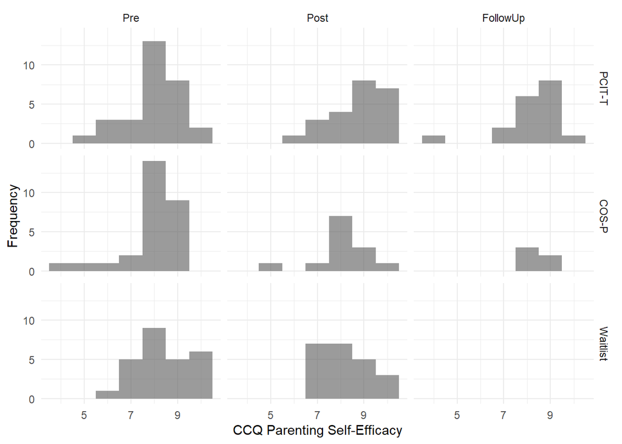

#### Model & Results

A linear mixed model with random effect for individual and fixed effects of group, time and the interaction was run. Estimated marginal means were obtained, and contrasts specified to test Hypothesis 1 and Hypothesis 2.

```
## fixed-effect model matrix is rank deficient so dropping 1 column / coefficient
```

```
## refitting model(s) with ML (instead of REML)
```

|  | Effect | npar | AIC | BIC | logLik | deviance | Chisq | Df | Pr(>Chisq) |
| --- | --- | --- | --- | --- | --- | --- | --- | --- | --- |
| result0 | Intercept | 3 | 480.872 | 490.190 | -237.436 | 474.872 | NA | NA | NA |
| result1 | Group | 5 | 483.632 | 499.161 | -236.816 | 473.632 | 1.240 | 2 | 0.538 |
| result2 | Time | 7 | 484.161 | 505.903 | -235.081 | 470.161 | 3.471 | 2 | 0.176 |
| result3 | Group*Time | 10 | 484.711 | 515.770 | -232.355 | 464.711 | 5.451 | 3 | 0.142 |

```r
summary(result3)
```

```
## Linear mixed model fit by REML. t-tests use Satterthwaite's method [
## lmerModLmerTest]
## Formula: outcome ~ group * time + (1 | id)
##    Data: dat
##
## REML criterion at convergence: 473.6
##
## Scaled residuals:
##     Min      1Q  Median      3Q     Max
## -3.8296 -0.3529  0.1137  0.5076  1.8504
##
## Random effects:
##  Groups   Name        Variance Std.Dev.
##  id       (Intercept) 0.5126   0.7159
##  Residual             0.6459   0.8037
## Number of obs: 165, groups:  id, 85
##
## Fixed effects:
##               Estimate Std. Error        df t value Pr(>|t|)
## (Intercept)    8.00278    0.19651 129.24749  40.725  < 2e-16 ***
## group2         0.04971    0.28282 129.24749   0.176  0.86075
## group3         0.36692    0.28784 130.65320   1.275  0.20466
## time2          0.65947    0.22881  85.95828   2.882  0.00499 **
## time3          0.34522    0.25012  88.95028   1.380  0.17098
## group2:time2  -0.62821    0.36998  95.02407  -1.698  0.09279 .
## group3:time2  -0.67991    0.33113  86.41633  -2.053  0.04307 *
## group2:time3  -0.04508    0.50097  99.59261  -0.090  0.92848
## ---
## Signif. codes:  0 '***' 0.001 '**' 0.01 '*' 0.05 '.' 0.1 ' ' 1
##
## Correlation of Fixed Effects:
##             (Intr) group2 group3 time2  time3  grp2:2 grp3:2
## group2      -0.695
## group3      -0.683  0.474
## time2       -0.479  0.333  0.327
## time3       -0.438  0.304  0.299  0.415
## group2:tim2  0.296 -0.426 -0.202 -0.618 -0.257
## group3:tim2  0.331 -0.230 -0.492 -0.691 -0.287  0.427
## group2:tim3  0.219 -0.315 -0.149 -0.207 -0.499  0.316  0.143
## fit warnings:
## fixed-effect model matrix is rank deficient so dropping 1 column / coefficient
```

#### Estimated Means & Change

Estimated means for each Treatment and Time are presented. In addition, within-group change between time points is presented with 95% CIs.

##### Group mean difference at each timepoint

Effect sizes all calculated by the pooled T1 SD of the outcome. Adjusted p-value from Bonferroni correction.

Group Differences at Each Time Point

| Group Difference | Time | Mean | SE | t | p | adj p | Lower CL | Upper CL | Effect Size | Lower CL | Upper CL |
| --- | --- | --- | --- | --- | --- | --- | --- | --- | --- | --- | --- |
| 1 - 2 | 1 | -0.050 | 0.283 | -0.176 | 0.983 | 1.000 | -0.720 | 0.621 | -0.043 | -0.574 | 0.504 |
| 1 - 3 | 1 | -0.367 | 0.288 | -1.275 | 0.412 | 0.614 | -1.049 | 0.316 | -0.319 | -0.874 | 0.215 |
| 2 - 3 | 1 | -0.317 | 0.293 | -1.084 | 0.526 | 0.841 | -1.011 | 0.377 | -0.276 | -0.894 | 0.219 |
| 1 - 2 | 2 | 0.578 | 0.359 | 1.613 | 0.243 | 0.327 | -0.270 | 1.427 | 0.504 | -0.211 | 1.215 |
| 1 - 3 | 2 | 0.313 | 0.315 | 0.995 | 0.581 | 0.965 | -0.432 | 1.058 | 0.273 | -0.337 | 0.836 |
| 2 - 3 | 2 | -0.266 | 0.363 | -0.732 | 0.745 | 1.000 | -1.124 | 0.593 | -0.231 | -0.846 | 0.401 |
| 1 - 2 | 3 | -0.005 | 0.495 | -0.009 | 1.000 | 1.000 | -1.176 | 1.166 | -0.004 | -0.958 | 1.001 |
| 1 - 3 | 3 | NA | NA | NA | NA | NA | NA | NA | NA | NA | NA |
| 2 - 3 | 3 | NA | NA | NA | NA | NA | NA | NA | NA | NA | NA |

* Effect size scaled by pooled T1 SD  
† ES 95% Bootstrapped Percentile CI limits  
‡ If you want a positive ES (and it is calculated as negative), be sure to switch the signs and positions of the lower and upper CIs.

##### Change within each group

Within-Group Change and Effect Sizes

| Change | Group | Mean | SE | t | p | adj p | Lower CL | Upper CL | Effect Size | Lower CL | Upper CL |
| --- | --- | --- | --- | --- | --- | --- | --- | --- | --- | --- | --- |
| 1 - 2 | 1 | -0.659 | 0.229 | -2.877 | 0.014 | 0.015 | -1.206 | -0.113 | -0.574 | -1.043 | -0.193 |
| 1 - 3 | 1 | -0.345 | 0.251 | -1.376 | 0.358 | 0.517 | -0.943 | 0.253 | -0.301 | -0.771 | 0.154 |
| 2 - 3 | 1 | 0.314 | 0.260 | 1.208 | 0.452 | 0.691 | -0.306 | 0.935 | 0.274 | -0.118 | 0.803 |
| 1 - 2 | 2 | -0.031 | 0.292 | -0.107 | 0.994 | 1.000 | -0.726 | 0.664 | -0.027 | -0.577 | 0.462 |
| 1 - 3 | 2 | -0.300 | 0.437 | -0.687 | 0.772 | 1.000 | -1.339 | 0.739 | -0.261 | -1.074 | 0.504 |
| 2 - 3 | 2 | -0.269 | 0.453 | -0.594 | 0.824 | 1.000 | -1.348 | 0.810 | -0.234 | -1.053 | 0.615 |
| 1 - 2 | 3 | 0.020 | 0.240 | 0.085 | 0.996 | 1.000 | -0.552 | 0.592 | 0.018 | -0.432 | 0.477 |
| 1 - 3 | 3 | NA | NA | NA | NA | NA | NA | NA | NA | NA | NA |
| 2 - 3 | 3 | NA | NA | NA | NA | NA | NA | NA | NA | NA | NA |

* Effect size scaled by pooled T1 SD  
† ES 95% Bootstrapped Percentile CI limits  
‡ If you want a positive ES (and it is calculated as negative), be sure to switch the signs and positions of the lower and upper CIs.

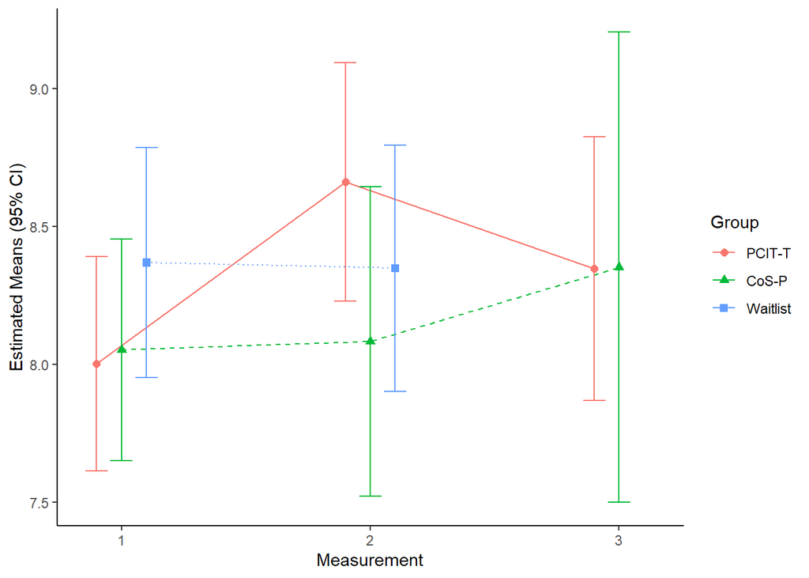

#### Hypothesis 1

We hypothesize that from baseline (‘T1’) to post-treatment/waitlist (‘T2’) there will be a gradient effect, whereby parent-child dyads who receive PCIT-T will show the greatest gains and parent-child dyads who receive no treatment will show the least gains. For the outcome, then, the null hypothesis is:

$H_0: \text {mean change}(\text{PCIT-T}) = \text {mean change}(\text{CoS-P}) = \text {mean change}(\text{Waitlist})$ $H_A: \text {mean change}(\text{PCIT-T}) > \text {mean change}(\text{CoS-P}) > \text {mean change}(\text{Waitlist})$

This is a joint hypothesis test.

First, confirming that the ordering of the means is as hypothesized:

```
## group = 1:
##  contrast estimate    SE    df t.ratio p.value
##  1 - 2     -0.6595 0.229  85.1  -2.877  0.0139
##  1 - 3     -0.3452 0.251  88.1  -1.376  0.3577
##  2 - 3      0.3142 0.260  82.9   1.208  0.4517
##
## group = 2:
##  contrast estimate    SE    df t.ratio p.value
##  1 - 2     -0.0313 0.292 100.2  -0.107  0.9937
##  1 - 3     -0.3001 0.437 102.5  -0.687  0.7716
##  2 - 3     -0.2689 0.453  90.5  -0.594  0.8237
##
## group = 3:
##  contrast estimate    SE    df t.ratio p.value
##  1 - 2      0.0204 0.240  86.0   0.085  0.9960
##  1 - 3      nonEst    NA    NA      NA      NA
##  2 - 3      nonEst    NA    NA      NA      NA
##
## Degrees-of-freedom method: kenward-roger
## P value adjustment: tukey method for comparing a family of 3 estimates
```

Now, to get the p-value associated with the joint hypothesis.

```
##   (Intercept) group2 group3 time2 time3 group2:time2 group3:time2 group2:time3
## 1           0      0      0     0     0           -1            0            0
## 2           0      0      0     0     1            0            1            0
```

```
##
##   General Linear Hypotheses
##
## Linear Hypotheses:
##        Estimate
## 1 == 0   0.6282
## 2 == 0  -0.3347
##
## Global Test:
##       F DF1 DF2 Pr(>F)
## 1 1.616   2 155 0.2021
```

So, the mean change for PCITT > COSP > Waitlist, but the pvalue>0.05. We fail to reject Hypothesis 1.

#### Hypothesis 2

There will be a gradient of size of change from T2 to T3 such that the change in the PCIT-T group > the change in the CoS-P group. This isn’t really a gradient; it’s just 1 hypothesis.

First, the change in PCITT and COSP from time 2 to time 3:

```
## group = 1:
##  contrast estimate    SE    df t.ratio p.value
##  1 - 2     -0.6595 0.229  85.1  -2.877  0.0139
##  1 - 3     -0.3452 0.251  88.1  -1.376  0.3577
##  2 - 3      0.3142 0.260  82.9   1.208  0.4517
##
## group = 2:
##  contrast estimate    SE    df t.ratio p.value
##  1 - 2     -0.0313 0.292 100.2  -0.107  0.9937
##  1 - 3     -0.3001 0.437 102.5  -0.687  0.7716
##  2 - 3     -0.2689 0.453  90.5  -0.594  0.8237
##
## group = 3:
##  contrast estimate    SE    df t.ratio p.value
##  1 - 2      0.0204 0.240  86.0   0.085  0.9960
##  1 - 3      nonEst    NA    NA      NA      NA
##  2 - 3      nonEst    NA    NA      NA      NA
##
## Degrees-of-freedom method: kenward-roger
## P value adjustment: tukey method for comparing a family of 3 estimates
```

```
##
##   Simultaneous Tests for General Linear Hypotheses
##
## Fit: lmer(formula = outcome ~ group * time + (1 | id), data = dat)
##
## Linear Hypotheses:
##        Estimate Std. Error z value Pr(>|z|)
## 1 == 0   0.5831     0.5202   1.121    0.262
## (Adjusted p values reported -- single-step method)
```

p>0.05, so we do not have enough evidence to suggest that the change from t2 to t3 in PCITT is greater than the change in COSP.

#### Residuals

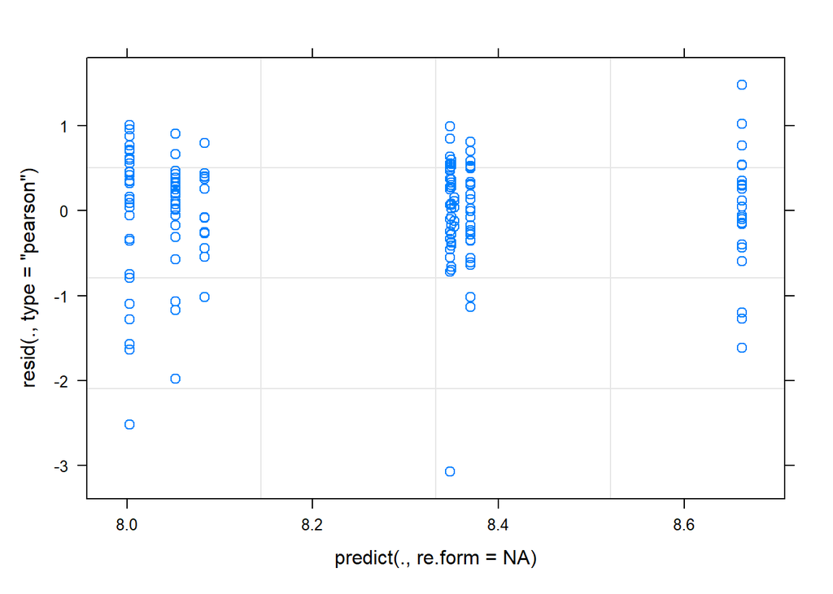

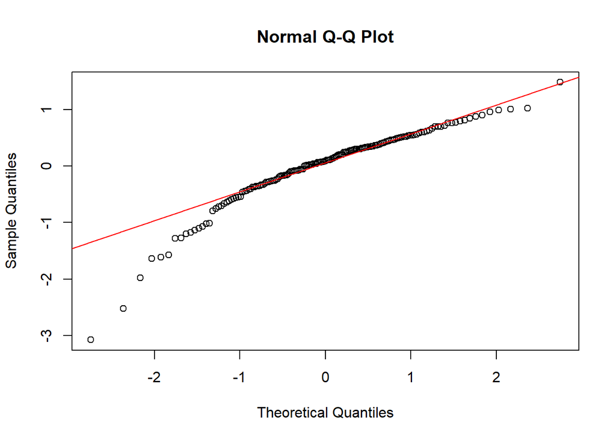

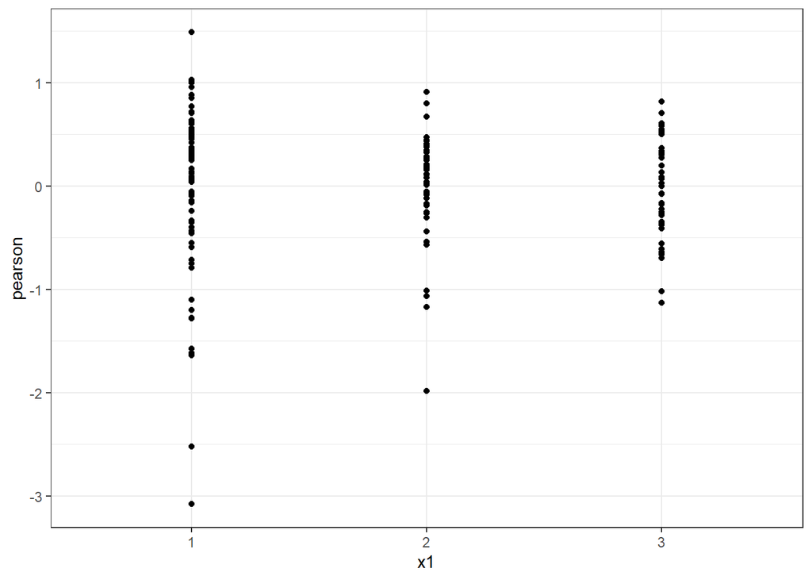

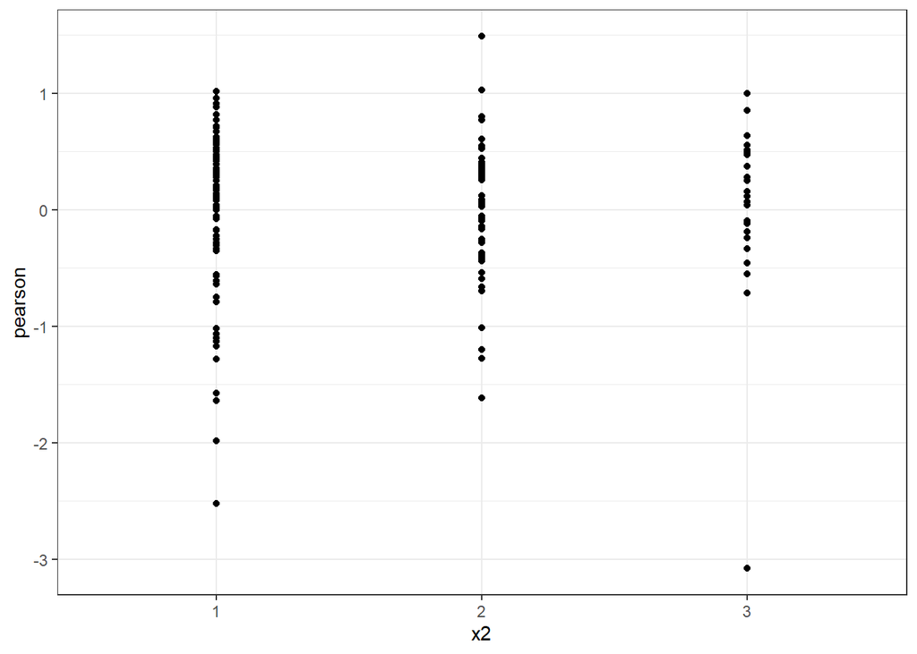

```r
rm(list = ls())
```